# Continued Analysis of The Compressive Strength of Concrete Mixures of Varying Composition

## DAT 402 Project 2

### Author - **Thomas Derr**

#### Dataset - https://www.kaggle.com/datasets/prathamtripathi/regression-with-neural-networking

## Import Libraries

```python
#The Basic Libraries
import pandas as pd
import matplotlib.pyplot as plt
import numpy as np

#Splittion and Analysis
from sklearn.model_selection import train_test_split
from sklearn.metrics import mean_squared_error
from sklearn.metrics import r2_score

#Modeling
from sklearn import linear_model
from sklearn import tree
from sklearn.ensemble import RandomForestRegressor
from sklearn.ensemble import GradientBoostingRegressor
```

## Intro

In Project 1, we performed ridge regression on our Concrete Compressive Strength dataset. Despite my best efforts with tuning the model in the last project, I was not able to get ridge regression to substantially and consistently outperform linear regression. There are several possible sources of error I would contribute to this, one being that I had not implemented a lasso. Additionally, the data is not nececarrily dependent on any linear factors. With further research into the nature of data analysis on compositional data (data that representing components adding to a whole), I found I might have been barking up the wrong tree. In the paper *Compositional Data and Their Analysis: An Introduction*, Vera Pawlowsky-Glahn and Juan José Egozcue make several enlightening statements in regards to how compositional data can cause issues when trying to create models without consideration.

"The properties peculiar to compositional data arise from the fact that they represent parts of some whole; therefore, they convey only relative information ... This fact conditions the relationships that variables have to one another - they are not free to vary independently in the way that unconstrained variables can"

There are several ways to approach solving this. In our case, the first thing we are going to do is move away from linear regression, and instead, we will be using a decision tree model. Additionally, instead of only using data from concrete that is 28 days old (like in the last project), I am going to allow age to be an independent variable in these models, as I originally had hoped that filtering it down in the last report would be beneficial in drawing conclusions about the importance of composition, but I beleive that age may play a larger part in compressive strength then I had previously thought

## Import and Clean Data

```python
#Import File
df = pd.read_csv('Concrete Compressive Strength.csv')

#For Easier Column Refference
age = 'Age (day)'
stren = 'Concrete compressive strength(MPa, megapascals) '
cem = 'Cement (component 1)(kg in a m^3 mixture)'
slag = 'Blast Furnace Slag (component 2)(kg in a m^3 mixture)'
ash = 'Fly Ash (component 3)(kg in a m^3 mixture)'
water = 'Water  (component 4)(kg in a m^3 mixture)'
plast = 'Superplasticizer (component 5)(kg in a m^3 mixture)'
coarse = 'Coarse Aggregate  (component 6)(kg in a m^3 mixture)'
fine = 'Fine Aggregate (component 7)(kg in a m^3 mixture)'

#Separate into X and y data (y = compressive strength, X = everything else)
X = df.drop(columns = [stren])
y = df[stren]

#Split X and y data for training and testing
Xtrain, Xtest, ytrain, ytest = train_test_split(X,y,test_size=0.3)
```

## Refresher From Last Project

In the last project we used a linear model to look at the data, so we will start by using the same method on the adjusted data set to get a better idea of the overall performance comparasin between the models in this project and the last one.

```python
# Using our same linear model on the data
linModel = linear_model.LinearRegression()
linModel.fit(Xtrain, ytrain)
yhat = linModel.predict(Xtest)
linearRMSE = np.sqrt(mean_squared_error(ytest, yhat))
```

## Showing Error for Linear Regression Model

Because of the multi-faceted nature of this data, instead of using $x$ values to show how the actual $y$ values deviate from a line of best fit, I am going to compare $y$ and $\hat{y}$ and show a line of equality. This is important to note as usually $x$ is linear and thus would be on the $x$ axis, and the line would represent the prediction of our linear model. In this case the line represents what a perfectly fitting model would show, and it will be important later to note that with this representation, as a model achieves a greater fit to the testing data, the dots will get closer to the line.

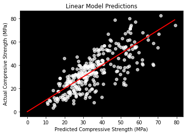

```python
# plot res
ax = plt.axes()
ax.set_facecolor("black")
plt.scatter(yhat, ytest, color = 'white', alpha = 0.7)
plt.title('Linear Model Predictions')
plt.xlabel('Predicted Compressive Strength (MPa)')
plt.ylabel('Actual Compresive Strength (MPa)')
plt.plot(np.array(range(80)), np.array(range(80)), linewidth=2, color='red')
plt.show()
```

## Decision Tree

A Decision Tree is a model differing from linear regression. As discussed in the class, it has many benefits over it such as

- Being able to capture non-linearity
- Working without having to councern ourselves with scaling
- Being easily usable or categorizagion or regression

It is for these reasons coupled with some of the drawbacks realized in the last project, that we will be using regression trees.

The best way to describe a decidion tree is as a set of rules. If we decide to look at it like a binary tree, these rules can be represented as nodes, and when we apply a rule we can take a "walk" down the "tree", with the traveled path determined by conditional statements on the paths.

```python
#Decision Tree
#calculate average rmse over 1000 re-trainings of the data
treeList = []
rmseList = []

for i in range(0,1000):
    #Add to Tree List
    tr = tree.DecisionTreeRegressor()
    tr = tr.fit(Xtrain, ytrain)
    treeList.append(tr)

    #Add To RMSE List
    yhat2 = tr.predict(Xtest)
    rmseList.append(np.sqrt(mean_squared_error(ytest, yhat2))) #add rmse to
```

#### Side Note

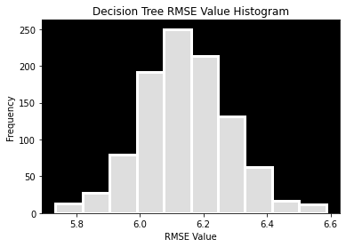

```python
#Plot distribution of the RMSE Values for our 1000 Decision Trees
ax = plt.axes()
ax.set_facecolor("black")
plt.hist(rmseList, facecolor = '#DEDEDE', edgecolor='#FFFFFF', linewidth=3, alpha = 1)
plt.xlabel('RMSE Value')
plt.ylabel('Frequency')
plt.title('Decision Tree RMSE Value Histogram')
```

## Showing Error for Decision Tree

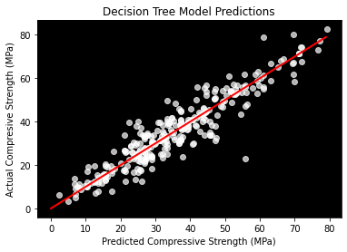

```python
ax = plt.axes()
ax.set_facecolor("black")
plt.scatter(yhat2, ytest, color = 'white', alpha = 0.7)
plt.title('Decision Tree Model Predictions')
plt.xlabel('Predicted Compressive Strength (MPa)')
plt.ylabel('Actual Compresive Strength (MPa)')
plt.plot(np.array(range(80)), np.array(range(80)), linewidth=2, color='red')
plt.show()
```

Note: Immediately we can see that this model's predicted strength is much closer to the actual values than those of the linear model.

```python
#Make dataframe with column 1 being all the trees, and column 2 being all of their rmse values
#We can sort by RMSE and choose the corresponding median tree
rmseAvg = sum(rmseList) / len(rmseList)
cols = {'Tree':treeList,'rmseVal':rmseList}
df2 = pd.DataFrame(cols)
decMeanRMSE = df2["rmseVal"].mean()  # average RMSE of all decision trees
```

## So What Does Our Tree Look Like?

```python
df2.sort_values(by=['rmseVal']) # sort trees in datafame by their RMSE's
ourTree = df2["Tree"][500] # select tree with median RMSE value We will end up using this one.
```

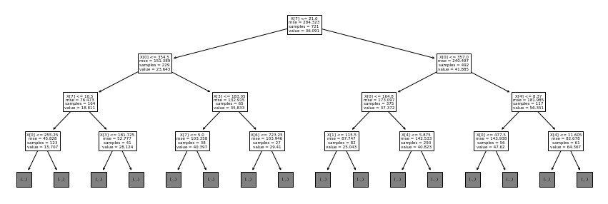

```python
plt.figure(figsize=(15, 5))
tree.plot_tree(ourTree, filled = False, max_depth=3) # tree plot
plt.show()
```

#### Just to get an idea of what the full tree looks like.

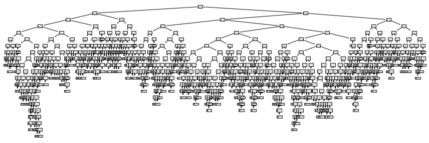

```python
plt.figure(figsize=(15, 5))
tree.plot_tree(ourTree, filled = False)
plt.show()
```

## Drawbacks to This Model

For Starters, It gets complicated... Really complicated (As evidenced by the graph of the tree above). It can take a lot of time and effort to get a tree that is more balanced than this, as for a dataset this size, a tree this big will usually overfit the data, and sub optimal pruning could end up making the model less accurate on the testing data. To combat this... we are introducing the gradient boosted decision tree.

## Gradient Boosted Decision Trees

A gradient boosted decision tree can provide a "boost" over our regular decision tree by iteratively fitting new decision trees to the residuals of the previous ones, and essentially building a strong model out of weaker ones. We will use this method to further improve on the error of our decision tree model.

```python
# Building our model
boost = GradientBoostingRegressor()
boost.fit(Xtrain, ytrain)
yhatBoost = boost.predict(Xtest)
boostRMSE = np.sqrt(mean_squared_error(ytest, yhatBoost)) #RMSE
```

## Showing Error For our Gradient Boosted Tree

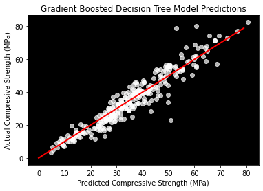

```python
ax = plt.axes()
ax.set_facecolor("black")
plt.scatter(yhatBoost, ytest, color = 'white', alpha = 0.7)
plt.title('Gradient Boosted Decision Tree Model Predictions')
plt.xlabel('Predicted Compressive Strength (MPa)')
plt.ylabel('Actual Compresive Strength (MPa)')
plt.plot(np.array(range(80)), np.array(range(80)), linewidth=2, color='red')
plt.show()
```

Note: Notice how this model's predicted strength is even closer to the actual values than those of the decision tree.

## Root Mean Squared Errors of our Models

```python
labels = ['Linear Regression', 'Decision Tree', 'Gratient Boosted Decision Tree']
allRMSE = [linearRMSE, decMeanRMSE, boostRMSE]
dfRMSE = pd.DataFrame(columns=[labels,allRMSE])

dfRMSE
```

|  | Linear Regression | Decision Tree | Gratient Boosted Decision Tree |
| --- | --- | --- | --- |
|  | 10.584958 | 6.143464 | 5.072819 |

## Works Cited

1. https://www.lyellcollection.org/doi/pdf/10.1144/gsl.sp.2006.264.01.01 - Compositional data and their analysis: an introduction V. PAWLOWSKY-GLAHN 1 & J. J. EGOZCUE 2